# Pump Neighborhoods

lindbrook

2016-09-25

## Overview

John Snow published two version of the Soho cholera map. The first, which appeared in *On The Mode Of Communication Of Cholera* (Snow 1855a), is more famous. The second, which appeared in the *Report On The Cholera Outbreak In The Parish Of St. James, Westminster, During The Autumn Of 1854* (Snow 1855b), is more important.

What makes it so is a graphical annotation that delineates the residences that Snow believes are most likely to use the Broad Street pump:

[figure not shown]

By identifying the pump’s neighborhood, Snow sets limits on where we should expect to find fatalities and, more importantly, where we should *not* expect to find fatalities. Ideally, this can help support his arguments that cholera is a waterborne disease and that the Broad Street pump is the source of the outbreak As Snow puts it: “it will be observed that the deaths either very much diminish, or cease altogether, at every point where it becomes decidedly nearer to send to another pump that to the one in Broad street” (Snow 1855b, 109).

To help assess Snow’s argument, I provide functions that allow one to analyze and visualize the two systematic approaches to computing pump neighborhoods: Voronoi tessellation, which is based on the Euclidean distance between pumps, and walking distance, which applies graph theory to the network of roads on Snow’s map of Soho. Regardless of the choice of computing neighborhoods (Snow’s annotation included), the guiding principle is straightforward: because fetching water entails physical effort, all else being equal, people will choose the closest pump. By aggregating these individual choices, pump neighborhoods emerge.

This package allows users not only to compare different methods, it also allows one to explore the data. First, one can consider different scenarios. For example, Snow argues that residents found the water from the Carnaby and Little Marlborough Street pump (#6) to be of low quality and actually preferred to actually go to the Broad Street pump instead (#7).[^1] Using this package, one can see and analyze the effect of excluding this pump. One can, in fact, include or exclude any set of pumps one wants. Second, one can compare the two different sets of pump: the 13 pumps in the original map and the 14 pumps in the Vestry Report.[^2]

### Voronoi tessellation

Cliff and Haggett (1988) appear to be the first to use Voronoi tessellation[^3] to describe the neighborhoods for the pumps on Snow’s original map. Dodson and Tolber (1992), in their digitization of the map, included coordinates for 13 Voronoi cells. These data are available in HistData::Snow.polygons. To replicate those results, I recompute the data using deldir::deldir(). With the exception of the border between the neighborhoods of the Market Place and the Adam and Eve Court pumps (pumps #1 and #2), Dodson and Tobler’s computation are otherwise identical.

To allow users to explore this method, I wrote voronoiPlot().

The figure below plots the “addresses” and the Voronoi cells for the 13 pumps in the original map.

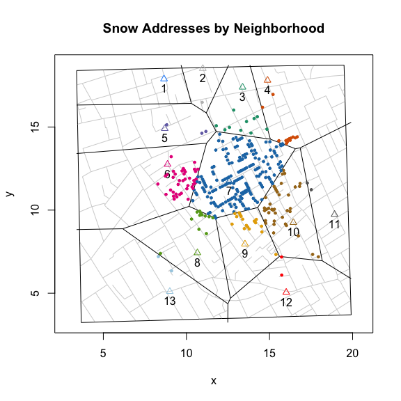

```r
voronoiPlot()
```

Snow wrote that some people who lived near the pump at Carnaby and Little Marlborough Street (#6) found its drinking water to be of low quality and actually preferred to go to the Broad Street pump. To explore this possibility, we can exclude that pump and replot the graph above.

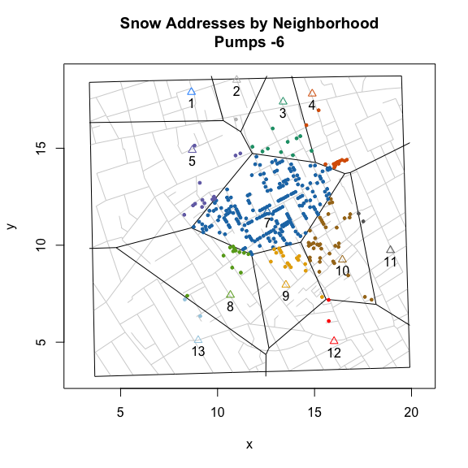

```r
voronoiPlot(select = -6)
```

For more information about voronoiPlot(), see the documentation.

### Walking distance

The most common criticism against applying Voronoi tessellation to Snow’s map is that it assumes that people walk directly to pumps in “as-the-crow-flies” fashion (i.e., Euclidean distance) rather than in indirect fashion along a network of roads.

Snow’s annotation is an attempt to addresses this issue. He writes that the annotation outlines “the various points which have been found by careful measurement to be at an equal distance by the nearest road from the pump in Broad Street and the surrounding pumps” (Snow 1855b, 109). In other words, the annotation appears to be based on a computation of walking distance. While the details of how Snow actually did this are lost to history, I replicate and extend his efforts by writitng functions that compute and visualize the weighted shortest paths between a fatality and its nearest pump.[^4] While the approach is by no means new, see Shiode (2012), I offer a more transparent, user-friendly way to apply this technique to Snow’s data.

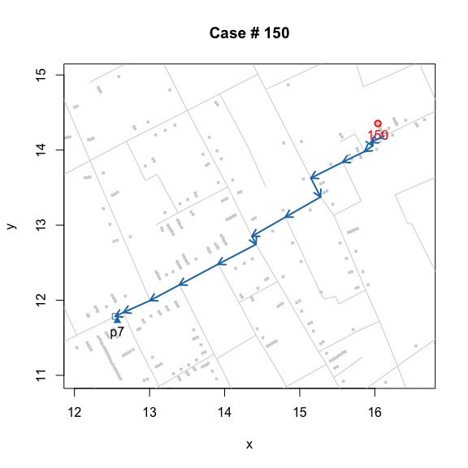

```r
walkingPathPlot(150)
```

By applying this function to all observed cases, we can begin to get a sense of the different pump neighborhoods.

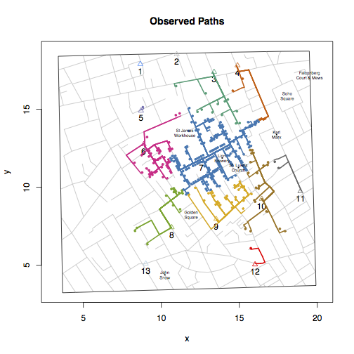

To get a sense of an entire neighborhood, I extend the approach from “observed” data to “expected” data. Using sp::spsample() and sp::Polygon(), I place 5000 regularly spaced points on the map and compute their walking path to the nearest pump. This allows me to see the full extent and range of a pump’s neighborhood.

I do so in two ways. In the first (Figure 8), I identify neighborhoods by coloring roads.[^5]

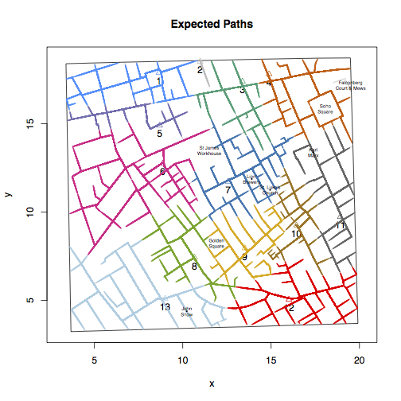

In the second, Figure 9, I identify neighborhoods by coloring regions.[^6].

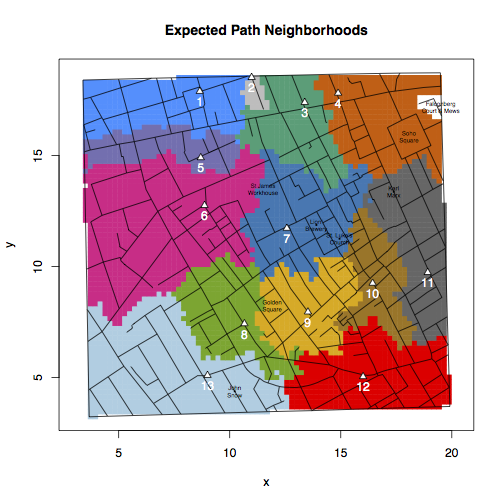

While the latter is easier to “read” (it is more familiar), it is potentially less accurate (or more misleading). Thematically, the problem is that the latter takes the focus away from where it should be, on roads and walking distances, and puts it on regions that do not have relevant meaning, points or locations where there is no residence or address. Computationally, the problem is that because off-road points are not really relevant deciding which points to color will be sensitive to the algorithm used. Depending on our choices, this can produce different results.[^7]

[^1]: Snow writes: “It requires to be stated that the water of the pump in Marlborough Street, at the end of Carnaby Street, was so impure that many persons avoided using it; and I found that the persons who died near this pump, in the beginning of September, had water from the Broad Street pump.”
[^2]: Note that in “pumps.vestry”, I eyeball estimate the location of the two amendments: the pump on Hanover Street and the relocation of the Broad Street Pump.
[^3]: http://www.ams.org/samplings/feature-column/fcarc-voronoi
[^4]: Another approach is to use GIS. For application that do not need to consider the actual historic walking distances, a layers-based approach, which relies on current rather than historical maps, may be sufficient: e.g., https://www.theguardian.com/news/datablog/2013/mar/15/john-snow-cholera-map. To reconstruct the roads represented on Snow’s map, consider the approach used by John Mackenzie (https://www1.udel.edu/johnmack/frec682/cholera/cholera2.html)l may be preferable.
[^5]: Shiode (2012) uses this approach.
[^6]: Mackenzie (N.D) uses this approach
[^7]: Cliff and Haggett also produce an adjusted Voronoi cells that reflect walking distances: “So far we have assumed that access to each pump was determined by ‘crow-fly’ distances. While the physical effort of carrying water mean that most people visited their nearest pump, recognition must be made of the complex street pattern in this area of London. Therefore in (D), the Thiessen polygons have been adjusted to take into account the patterns of access made possible by the street system shown in diagram (A) (Cliff and Haggett 1988, 53). However, details about how this was done do not appear to be available. Moreover, because the graphic only shows the outline of the polygon and not the streets, comparisons with other approaches is difficult.